# Developing Data Products - Project

Kapil Wadodkar

21 June 2015

# Problem Background

This is presentation for Shiny app developed as part of title: “Developing Data Products - Project”

This app will help to predict possible MPG against variables like: - Horsepower - Cylinders count - Weight (in lbs)

# Dataset in Use - mtcars dataset

The `mtcars` dataset can be used to build a model of the effects of car characteristics on fuel efficiency. An example of the data is below:

```r
data(mtcars); library(xtable)
print(xtable(mtcars[1:8,]), type = "html")
```

|  | mpg | cyl | disp | hp | drat | wt | qsec | vs | am | gear | carb |
| --- | --- | --- | --- | --- | --- | --- | --- | --- | --- | --- | --- |
| Mazda RX4 | 21.00 | 6.00 | 160.00 | 110.00 | 3.90 | 2.62 | 16.46 | 0.00 | 1.00 | 4.00 | 4.00 |
| Mazda RX4 Wag | 21.00 | 6.00 | 160.00 | 110.00 | 3.90 | 2.88 | 17.02 | 0.00 | 1.00 | 4.00 | 4.00 |
| Datsun 710 | 22.80 | 4.00 | 108.00 | 93.00 | 3.85 | 2.32 | 18.61 | 1.00 | 1.00 | 4.00 | 1.00 |
| Hornet 4 Drive | 21.40 | 6.00 | 258.00 | 110.00 | 3.08 | 3.21 | 19.44 | 1.00 | 0.00 | 3.00 | 1.00 |
| Hornet Sportabout | 18.70 | 8.00 | 360.00 | 175.00 | 3.15 | 3.44 | 17.02 | 0.00 | 0.00 | 3.00 | 2.00 |
| Valiant | 18.10 | 6.00 | 225.00 | 105.00 | 2.76 | 3.46 | 20.22 | 1.00 | 0.00 | 3.00 | 1.00 |
| Duster 360 | 14.30 | 8.00 | 360.00 | 245.00 | 3.21 | 3.57 | 15.84 | 0.00 | 0.00 | 3.00 | 4.00 |
| Merc 240D | 24.40 | 4.00 | 146.70 | 62.00 | 3.69 | 3.19 | 20.00 | 1.00 | 0.00 | 4.00 | 2.00 |

Ref: mtcars dataset - https://stat.ethz.ch/R-manual/R-devel/library/datasets/html/mtcars.html

# Methodology used for prediction

With mtcars dataset and liner modeling the effect of horsepower, number of cylinders, and weight on the mpg. Restricting cylinder selection to 4, 6, and 8 with radio buttons. For the weight, reactive() is used to convert the user input weight into the units used by the model, lb/1000. A linear model function is used to predict the mpg based on the three variables input by the user.

```r
modelFit <- lm(mpg ~ hp + cyl + wt, data=mtcars)
modelFit$coefficients
```

```
## (Intercept)          hp         cyl          wt
##  38.7517874  -0.0180381  -0.9416168  -3.1669731
```

```r
mpg <- function(hp, cyl, wt) {
    modelFit$coefficients[1] + modelFit$coefficients[2] * hp +
        modelFit$coefficients[3] * cyl + modelFit$coefficients[4] * wt
}
```

# Application details

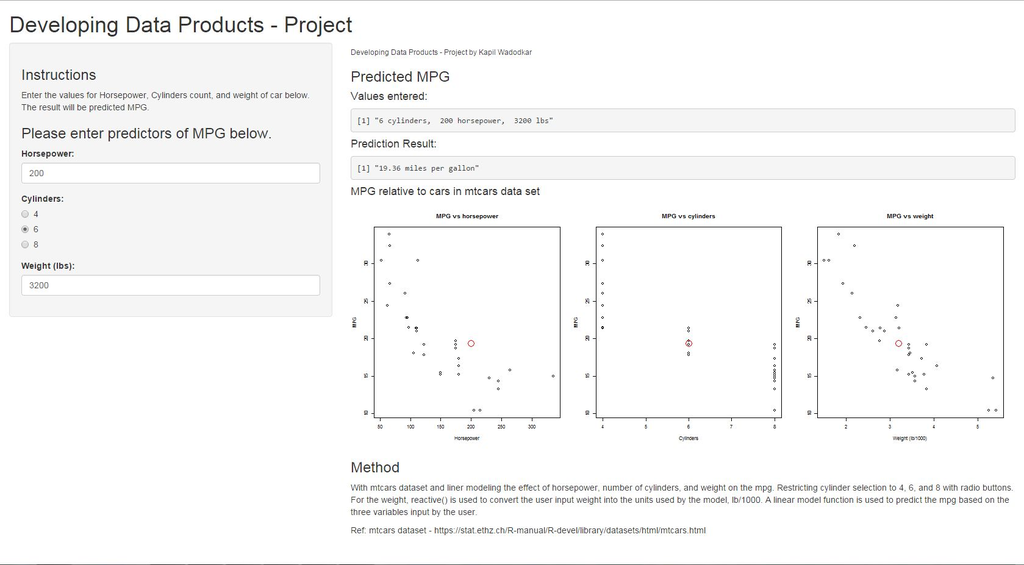

User will be providing inputs at left panel. Output will be provided and will be compared with mtcars data in central panel.